# DATA 624 Homework 1

## Question 2.1

Use the help function to explore what the series `gold`, `woolyrnq` and `gas` represent.

**`gold` is the daily morning gold prices in US dollars from 1 Jan 1985 to 31 March 1989. `woolyrnq` is the quarterly production of woolen yarn in Australia in tons from March 1965 to September 1994. `gas` is monthly gas production in Australia from 1956-1995.**

1. Use `autoplot()` to plot each of these in separate plots.

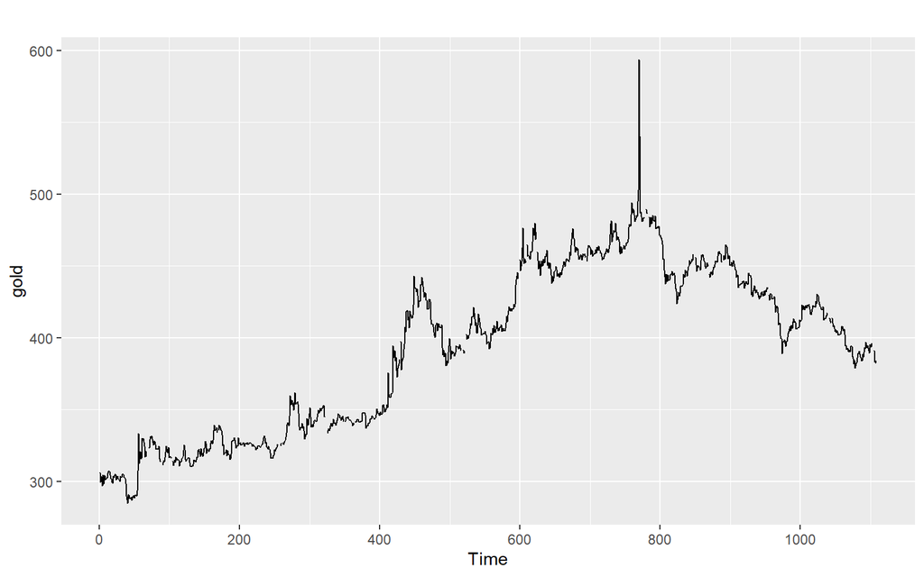

```r
autoplot(gold)
```

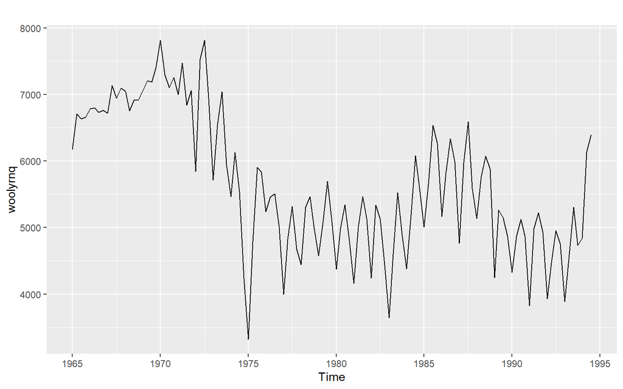

```r
autoplot(woolyrnq)
```

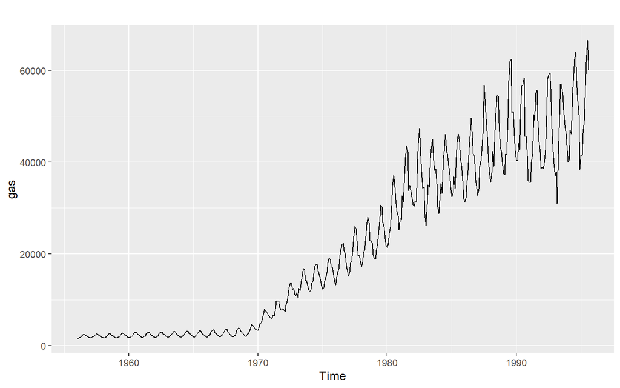

```r
autoplot(gas)
```

2. What is the frequency of each series? Hint: apply the `frequency()` function.

```r
frequency(gold)
```

```
[1] 1
```

```r
frequency(woolyrnq)
```

```
[1] 4
```

```r
frequency(gas)
```

```
[1] 12
```

3. Use `which.max()` to spot the outlier in the gold series. Which observation was it?

```r
goldoutlier <- which.max(gold)
```

**It is the 770 observation. The price of gold was 593.7**

## Queston 2.2

Download the file `tute1.csv` from the book website, open it in Excel (or some other spreadsheet application), and review its contents. You should find four columns of information. Columns B through D each contain a quarterly series, labelled Sales, AdBudget and GDP. Sales contains the quarterly sales for a small company over the period 1981-2005. AdBudget is the advertising budget and GDP is the gross domestic product. All series have been adjusted for inflation.

1. You can read the data into R with the following script:

```r
if(!file.exists("tute1.csv")){
  download.file("http://otexts.com/fpp2/extrafiles/tute1.csv", "tute1.csv")
}
tute1 <- read.csv("tute1.csv", header=TRUE)
View(tute1)
```

2. Convert the data to time series

```r
mytimeseries <- ts(tute1[,-1], start=1981, frequency=4)
```

(The [,-1] removes the first column which contains the quarters as we don’t need them now.)

3. Construct time series plots of each of the three series

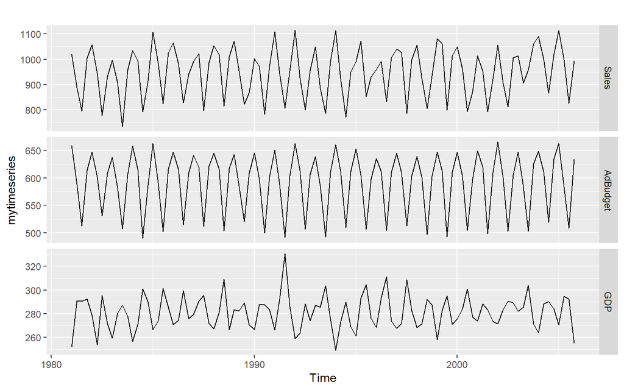

```r
autoplot(mytimeseries, facets=TRUE)
```

Check what happens when you don’t include facets=TRUE.

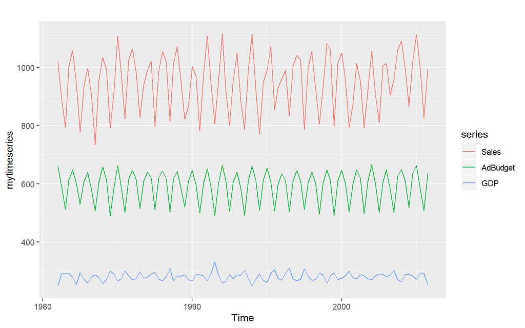

```r
autoplot(mytimeseries)
```

**It stacks the visualization instead of having small multiples.**

## Question 2.3

Download some monthly Australian retail data from the book website. These represent retail sales in various categories for different Australian states, and are stored in a MS-Excel file.

1. You can read the data into R with the following script:

```r
if(!file.exists("retail.xlsx")){
  download.file("https://otexts.com/fpp2/extrafiles/retail.xlsx", "retail.xlsx")
}
retaildata <- readxl::read_excel("retail.xlsx", skip=1)
```

The second argument (skip=1) is required because the Excel sheet has two header rows.

2. Select one of the time series as follows (but replace the column name with your own chosen column):

```r
myts <- ts(retaildata[,"A3349873A"], frequency=12, start=c(1982,4))
```

3. Explore your chosen retail time series using the following functions:

`autoplot()`, `ggseasonplot()`, `ggsubseriesplot()`, `gglagplot()`, `ggAcf()`

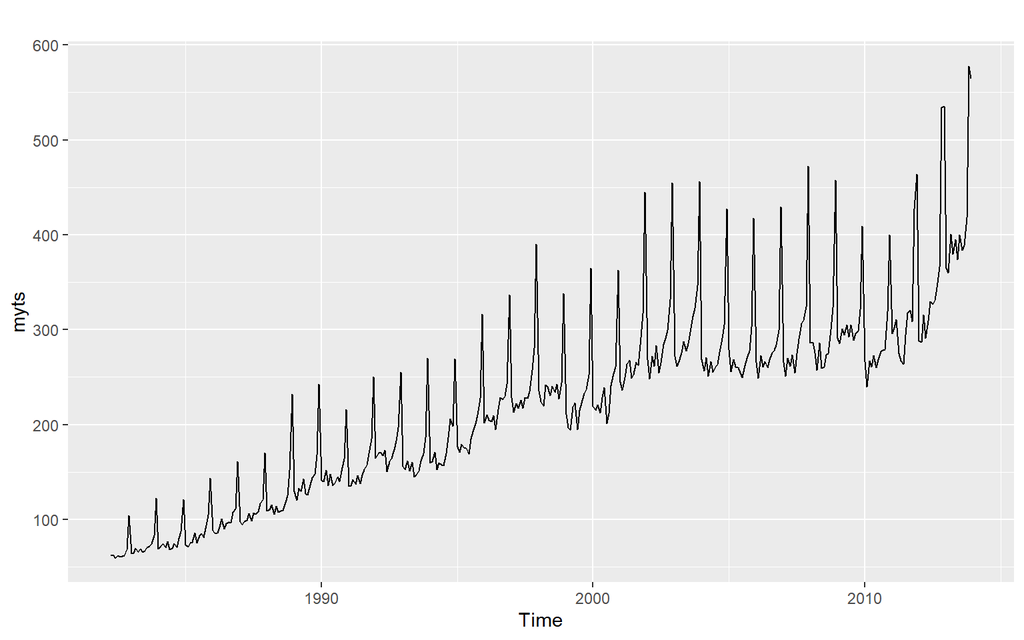

```r
autoplot(myts)
```

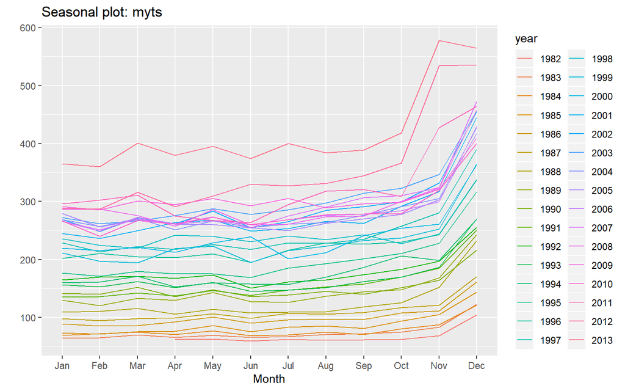

```r
ggseasonplot(myts)
```

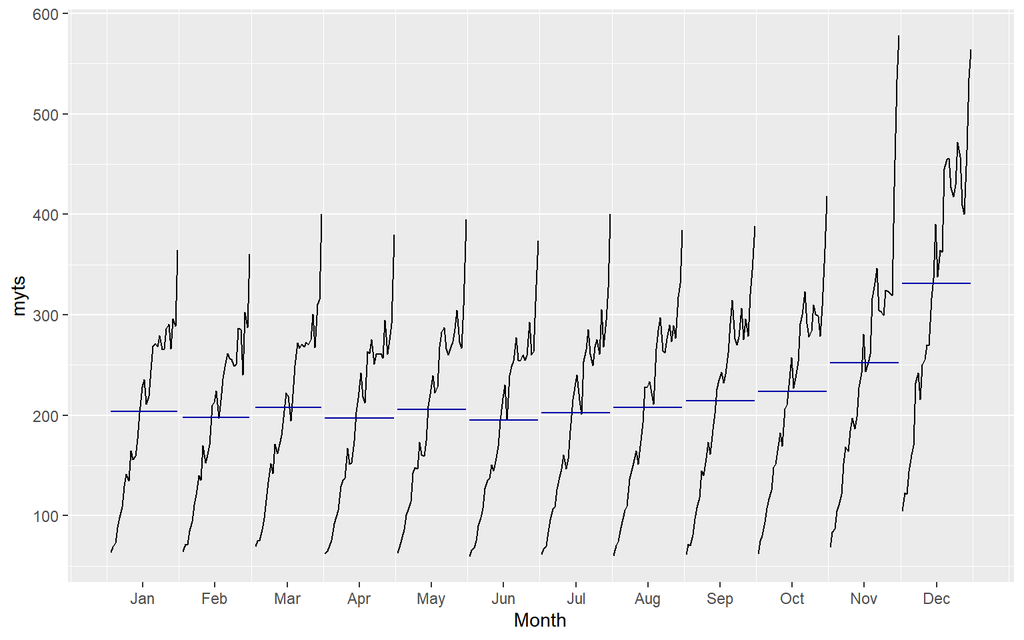

```r
ggsubseriesplot(myts)
```

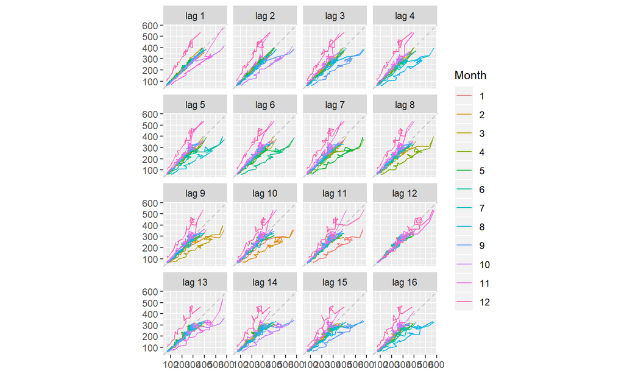

```r
gglagplot(myts)
```

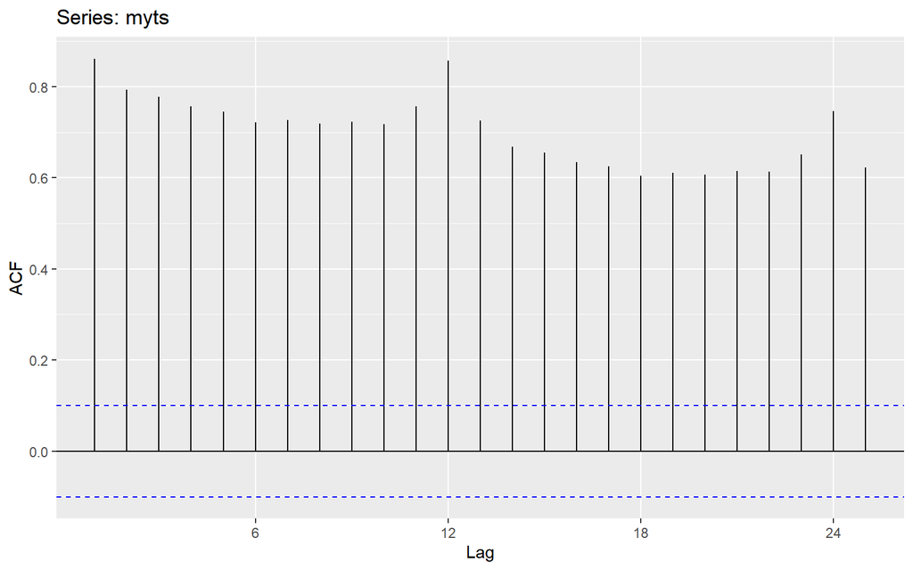

```r
ggAcf(myts)
```

Can you spot any seasonality, cyclicity and trend? What do you learn about the series?

**There is a clear seasonality increase in retail sales from October to the end of the year. This is the Christmas shopping season. There is also a trend of increasing retail sales over time. The trend has been rising untill the 2000’s where it flatened out for roughly a decade. Since 2010 it looks like the trend increases again.**

## Question 2.6

Use the following graphics functions: `autoplot()`, `ggseasonplot()`, `ggsubseriesplot()`, `gglagplot()`, `ggAcf()` and explore features from the following time series: `hsales`, `usdeaths`, `bricksq`, `sunspotarea`, `gasoline`.

### hsales

- Can you spot any seasonality, cyclicity and trend?

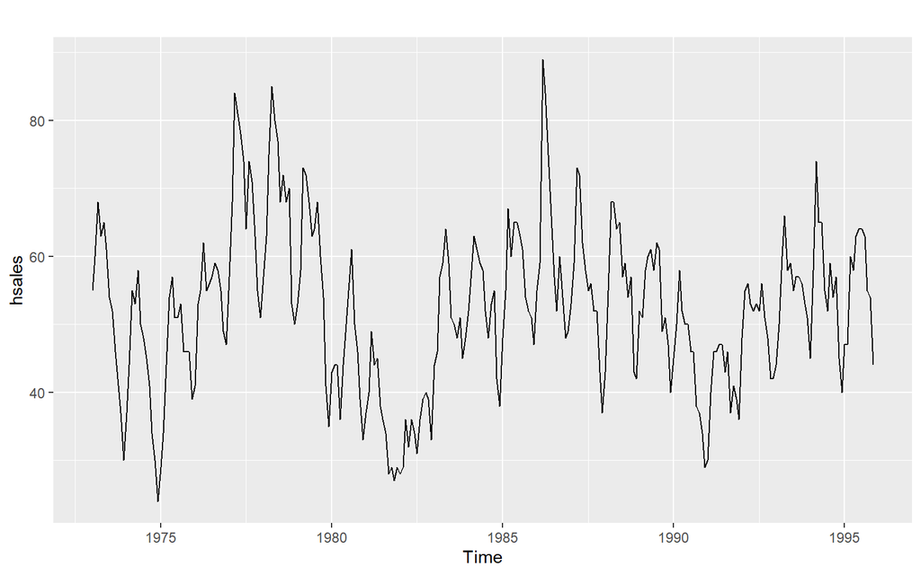

```r
autoplot(hsales)
```

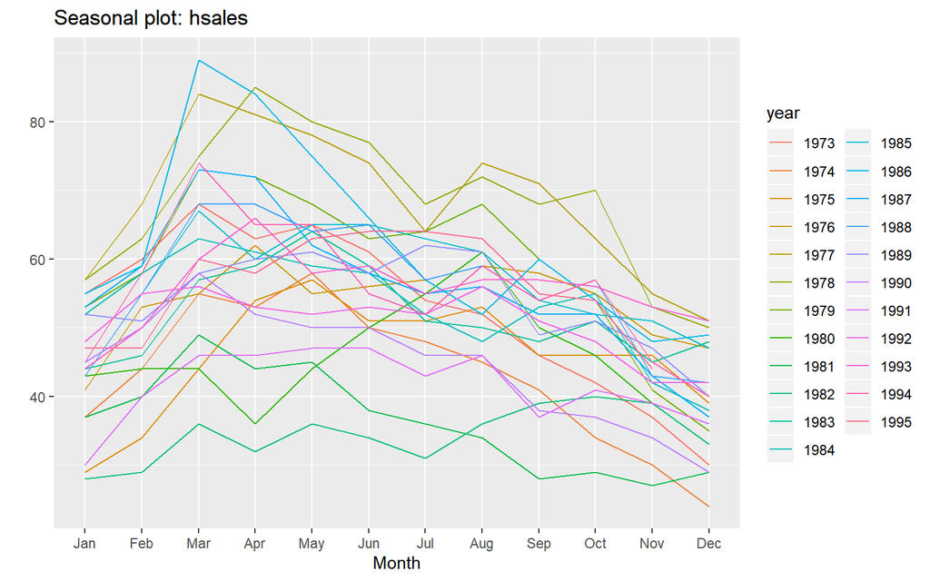

```r
ggseasonplot(hsales)
```

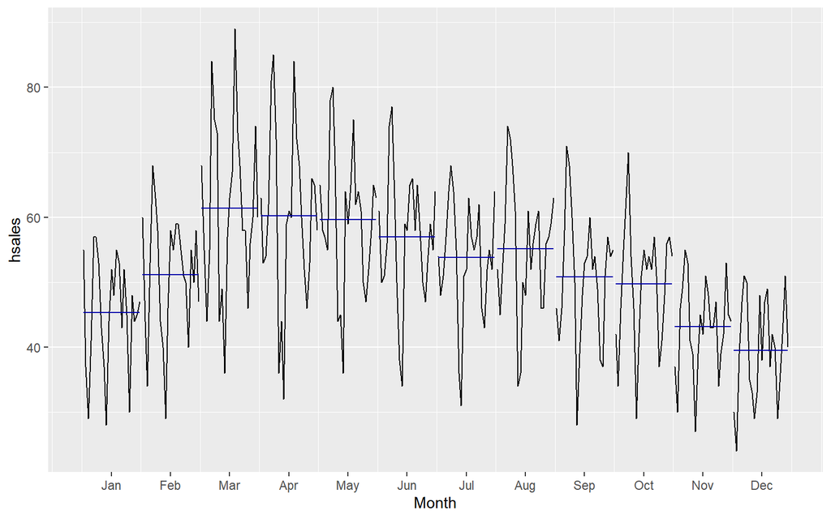

```r
ggsubseriesplot(hsales)
```

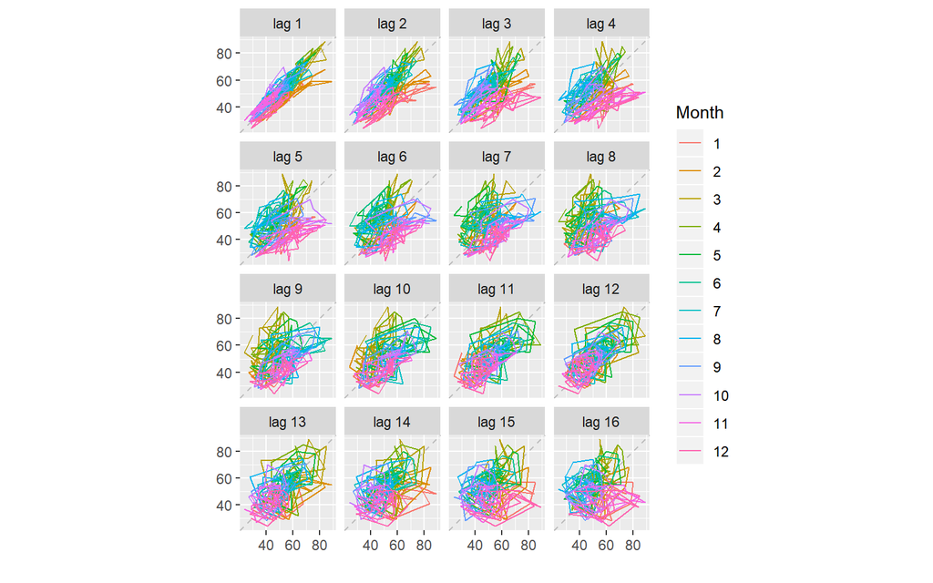

```r
gglagplot(hsales)
```

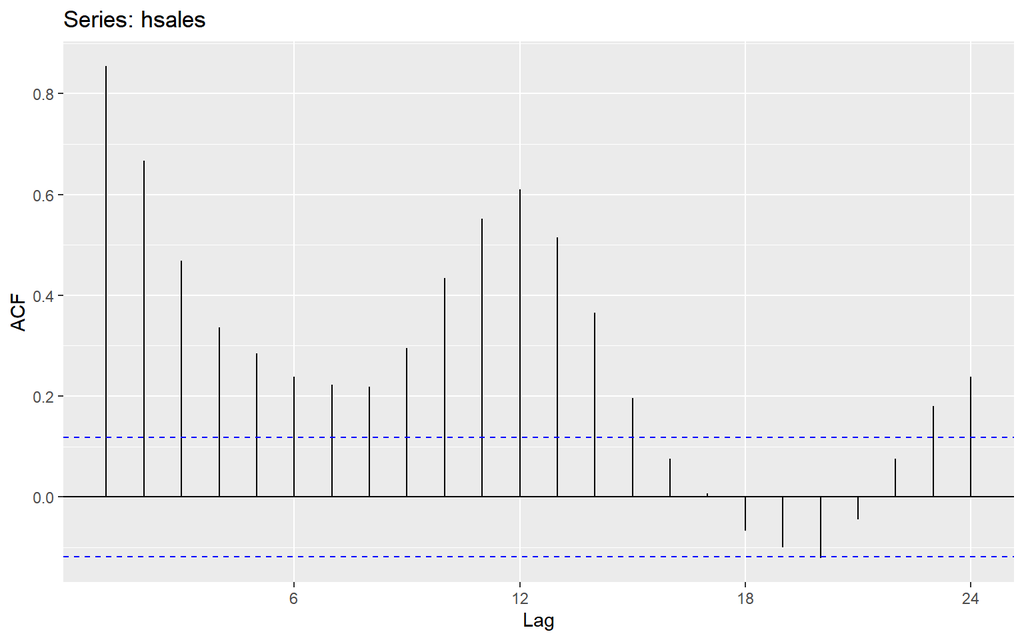

```r
ggAcf(hsales)
```

**One-family home sales in the US tend to be highest in March. The ACF plot suggests that there is some annual cycle, but it is noisy.**

- What do you learn about the series?

**If I am a realtor I’m not going to be busy in the winter months. Early spring (march through may) will be my busy time of the year.**

### usdeaths

- Can you spot any seasonality, cyclicity and trend?

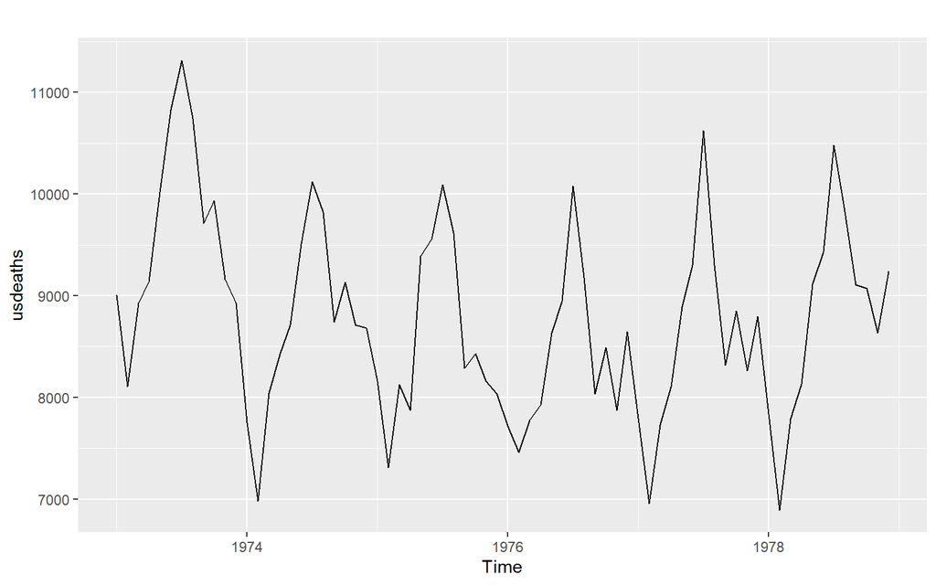

```r
autoplot(usdeaths)
```

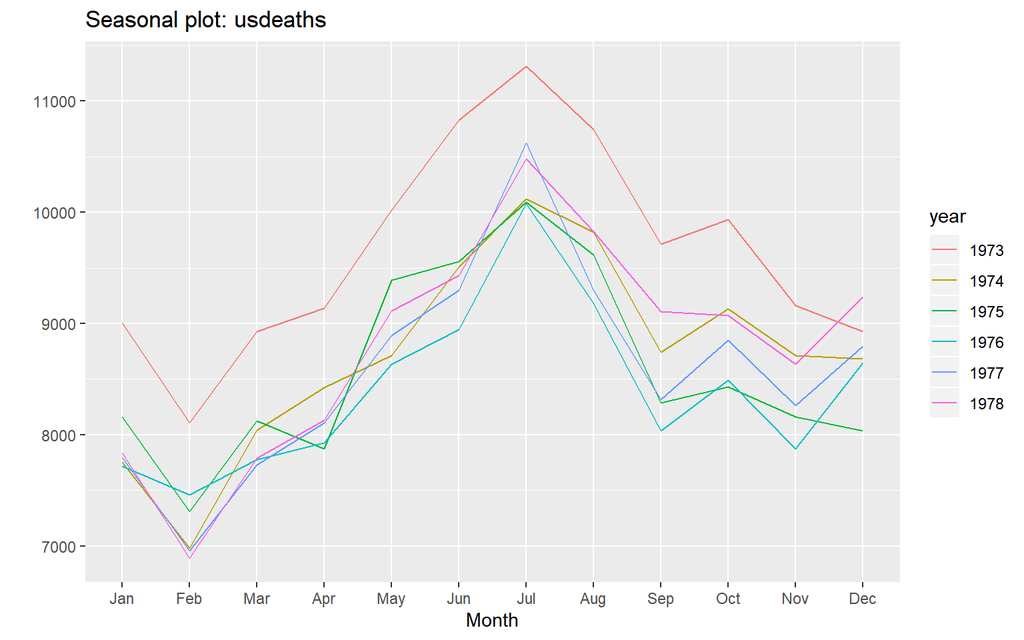

```r
ggseasonplot(usdeaths)
```

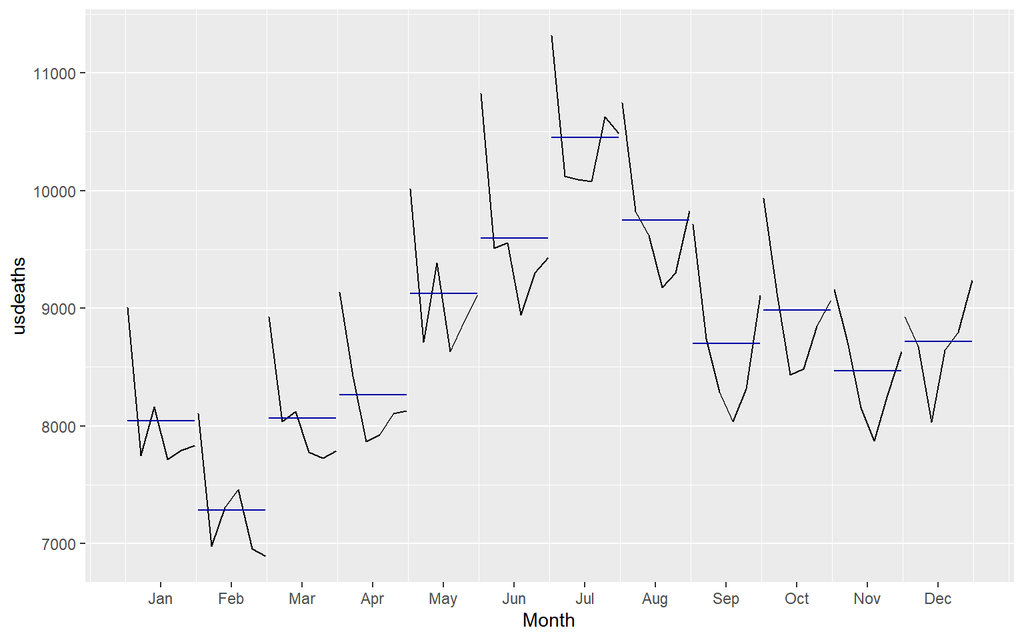

```r
ggsubseriesplot(usdeaths)
```

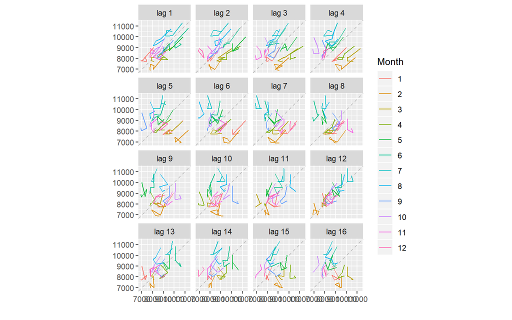

```r
gglagplot(usdeaths)
```

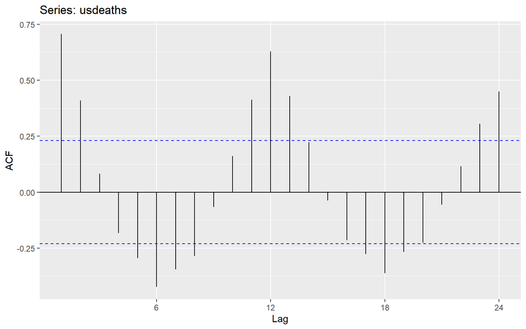

```r
ggAcf(usdeaths)
```

**There appears to be a seasonal pattern to the data.**

- What do you learn about the series?

**Accidental deaths in the US tends to be highest in July.**

### bricksq

- Can you spot any seasonality, cyclicity and trend?

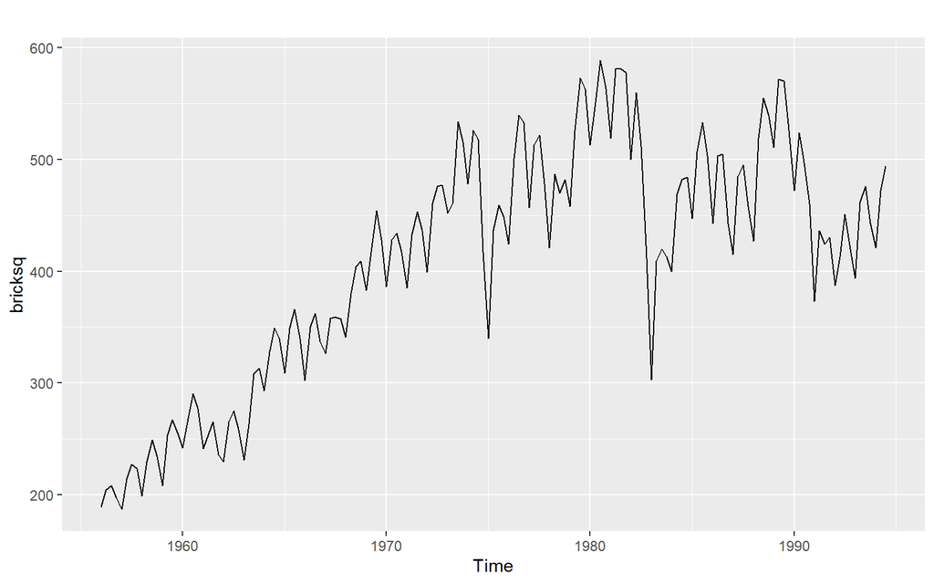

```r
autoplot(bricksq)
```

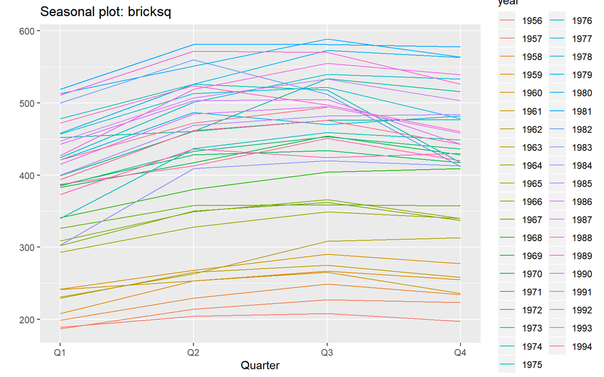

```r
ggseasonplot(bricksq)
```

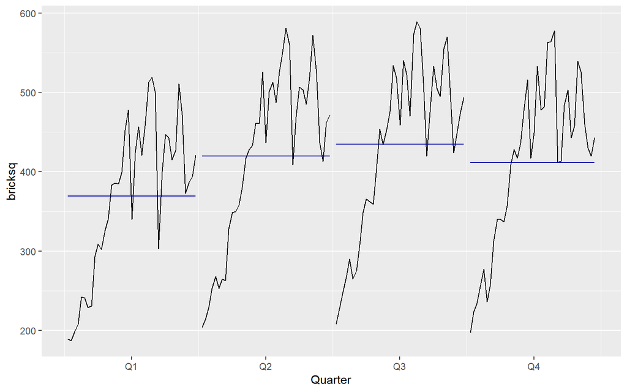

```r
ggsubseriesplot(bricksq)
```

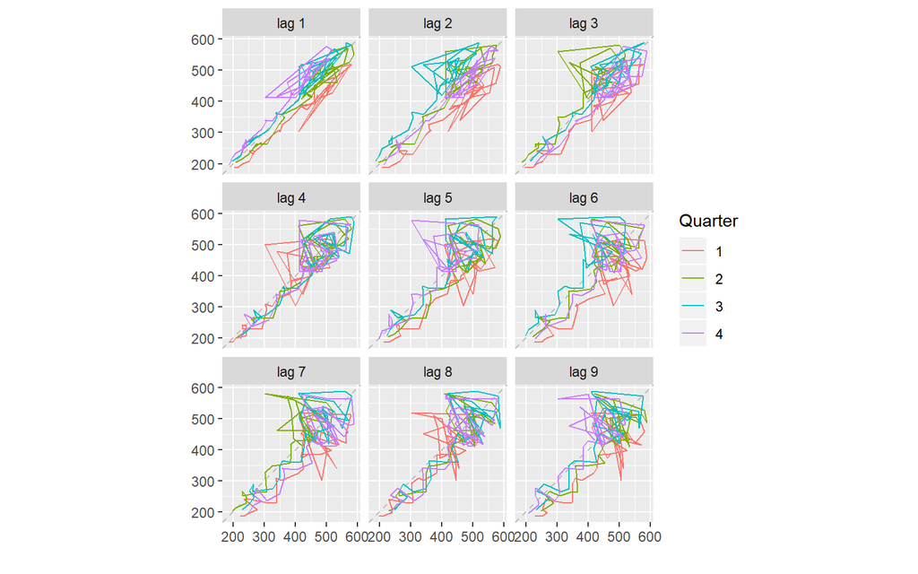

```r
gglagplot(bricksq)
```

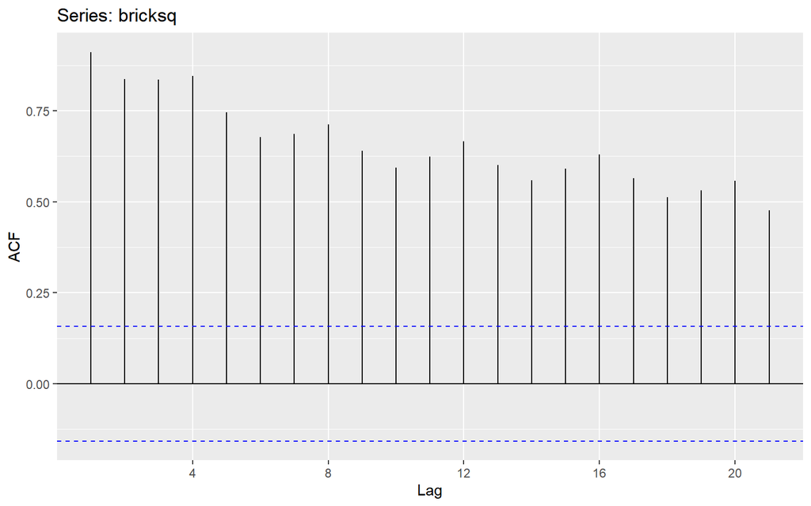

```r
ggAcf(bricksq)
```

**There isn’t much variation from Q2 through Q4. The trend was genrally increasing until about the 1980’s.**

- What do you learn about the series?

**Q1 is a slow quarter for Australian clay brick producers. There has been quite a bit more irregularity since 1975.**

### sunspotarea

- Can you spot any seasonality, cyclicity and trend?

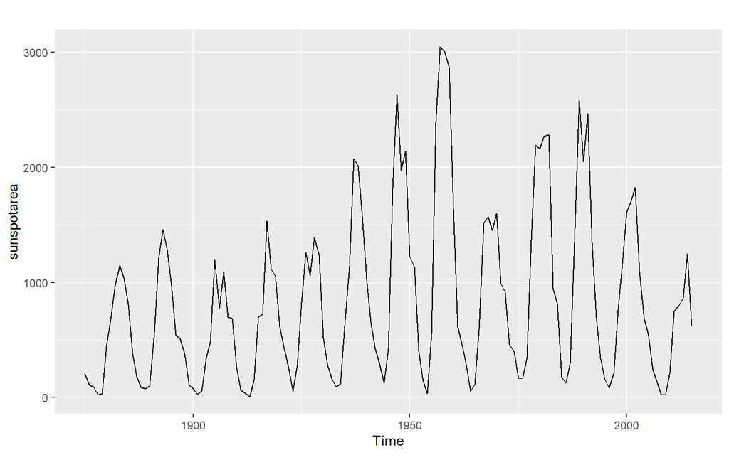

```r
autoplot(sunspotarea)
```

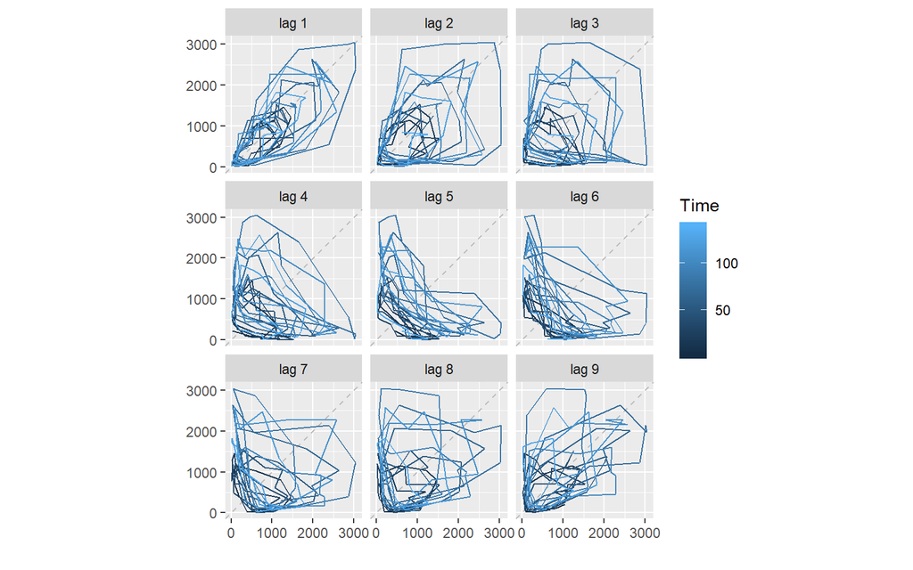

```r
#ggseasonplot(sunspotarea)
#ggsubseriesplot(sunspotarea)
gglagplot(sunspotarea)
```

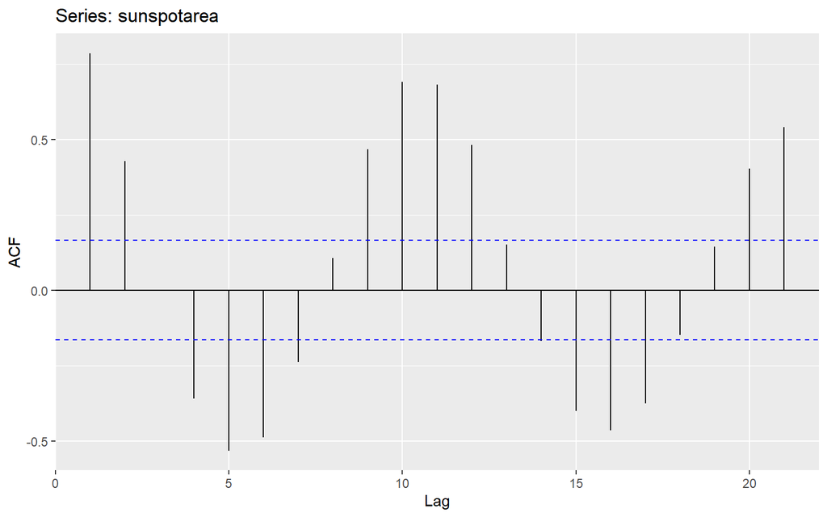

```r
ggAcf(sunspotarea)
```

**There appears to be a cycle in the data. It looks like it’s about a 10 to 11 year cycle.**

- What do you learn about the series?

**If the pattern holds 2020 should be a year with low sunspot area.**